# Lakes and wetlands analysis

```r
# Import package for geographical clustering
library(ClustGeo)
# Import libraries for enhanced plotting
library(dplyr)
library(RColorBrewer)
library(scales)
# Read in the datafile
data<-read.csv("glwd_1.csv")
```

Colour maps to be used in the figures.

```r
reds<-c("#FFF5F0", "#FEE0D2", "#FCBBA1", "#FC9272", "#FB6A4A", "#EF3B2C",
        "#C0181D", "#A00F15", "#700000", "#400000")
blues<-c("#F7FBFF", "#DEEBF7", "#C6DBEF", "#9ECAE1", "#6BAED6", "#4292C6",
         "#2171B5", "#08519C", "#000070", "#000040")
greens<-c("#F7FCF5", "#E5F5E0", "#C7E9C0", "#A1D99B", "#74C476", "#41AB5D",
          "#238B45", "#006D2C", "#004000", "#000400")
```

# Variable explanations

*ELEV_M*: contains the elevation from sea level in meters.

*AREA_SKM*: area of the lake in square kilometers. There are some differences compared to other sources, but there is even more variability when compared to other sources further. It seems that there might be some distinction behind the difference, perhaps time of measurement.

*LONG_DEG* and *LAT_DEG*: these show the coordinates of the body of water.

*COUNTRY*: shows the country, where the lake is situated. If there are multiple countries, other countries are listed in *SEC_CNTRY*.

*TYPE*: tells us whether the body of water is a lake or a reservoir.

The dataset contains other variables as well, which are not considered here.

# Tentative exploratory analysis

Let us start by drawing histograms of the *AREA_SKM* variable. Since the difference between the smallest and largest lakes is so big, we will draw multiple figures using cutoffs.

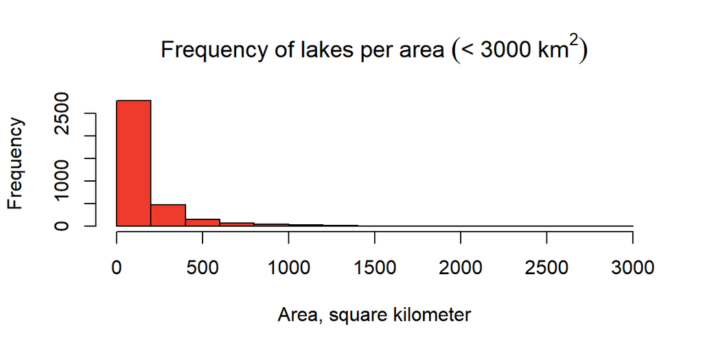

```r
hist(data[data$AREA<3000,]$AREA, main=expression(Frequency~of~lakes~per~area~
                                                   ("\u{003C}"~3000~km^2)),
     xlab="Area, square kilometer", ylab="Frequency", col=reds[6])
```

From the figure, we see that a majority of the areas are between 0 and 500 square kilometers. Let us look more closely, how the frequency behaves as the area grows.

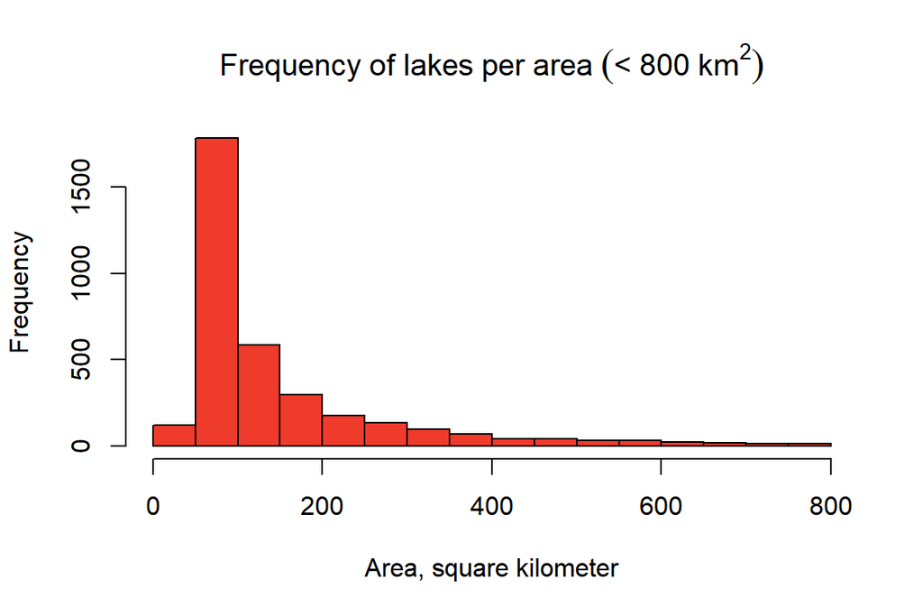

```r
hist(data[data$AREA<800,]$AREA, main=expression(Frequency~of~lakes~per~area~
                                                  ("\u{003C}"~800~km^2)),
     xlab="Area, square kilometer", ylab="Frequency", col=reds[6])
```

Here we see that there are not as many datapoints at the lowest bin. This is most likely because the dataset is limited, so very small lakes are more likely to not be modeled here. In addition, we see from the figure that the frequency decreases steadily as the area grows.

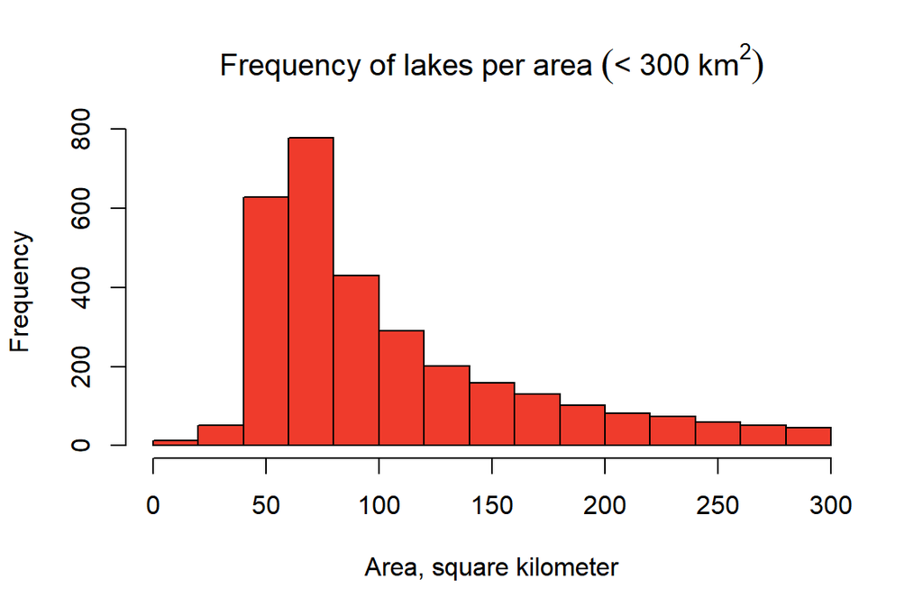

```r
hist(data[data$AREA<300,]$AREA, main=expression(Frequency~of~lakes~per~area~
                                                  ("\u{003C}"~300~km^2)),
     xlab="Area, square kilometer", ylab="Frequency", col=reds[6])
```

Next, we will draw a histogram of the elevation.

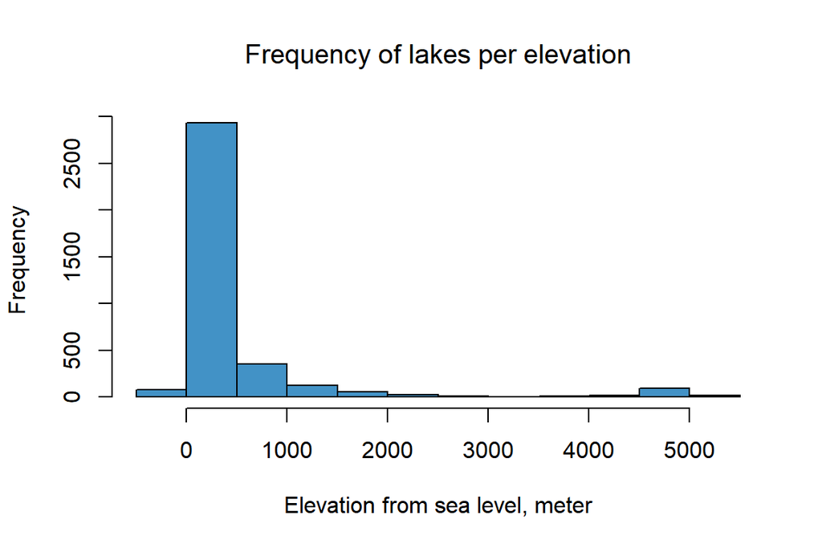

```r
hist(data$ELEV, main=expression(Frequency~of~lakes~per~elevation),
     xlab="Elevation from sea level, meter", ylab="Frequency", col=blues[6])
```

Similarly to the area, there are some lakes at very high altitudes, while most lakes are at roughly sea level. Here we can split the lakes and draw the figure based on a cutoff-point again. First, let us see what the elevation is in the lowest elevated lakes.

```r
sort(data$ELEV)[1:10]
```

```
##  [1] -405 -404 -202  -74  -74  -22  -22  -22  -12  -12
```

There are only three lakes with an elevation of under -100 meters. For the first figure, we will only consider the lakes with a higher elevation than this up to an elevation of 1000 meters. In the second figure, we will look at the gap between the lakes at roughly sea level and the very high altitude lakes at around 5000 meters. Finally, we will look at those high altitude lakes in a final third figure.

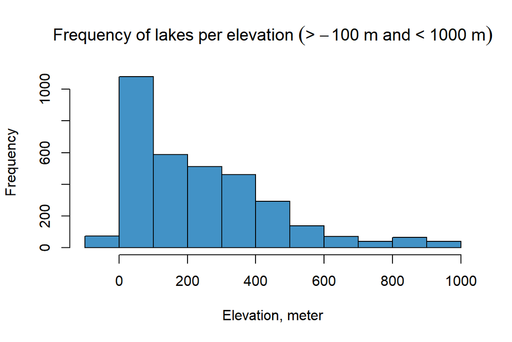

```r
hist(data[data$ELEV>-100&data$ELEV<1000,]$ELEV, main=expression(Frequency~of~
                            lakes~per~elevation~(">"~-100~m~and~"<"~1000~m)),
     xlab="Elevation, meter", ylab="Frequency", col=blues[6])
```

From this figure we see that the frequency of lakes above sea level and under 100 meters is the greatest. As the elevation rises, the frequency decreases up to an elevation of around 500 meters. After that point, based on this figure, there appears to be an equal amount of lakes at each bin. We can look at this more closely in the following figure:

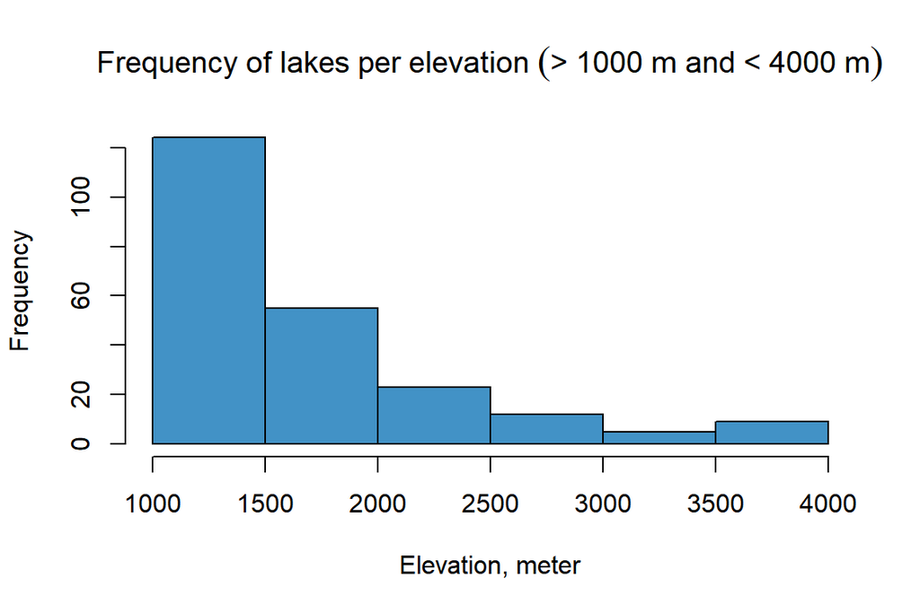

```r
hist(data[data$ELEV>1000&data$ELEV<4000,]$ELEV, main=expression(Frequency~of~
                              lakes~per~elevation~(">"~1000~m~and~"<"~4000~m)),
     xlab="Elevation, meter", ylab="Frequency", col=blues[6])
```

Here we see that the frequency of lakes does in fact still decrease with elevation at over 500 meters. This decrease slows down at around 3000 meters elevation. Here, at an elevation of between 2000 meters and 4000 meters, there are not very many datapoints.

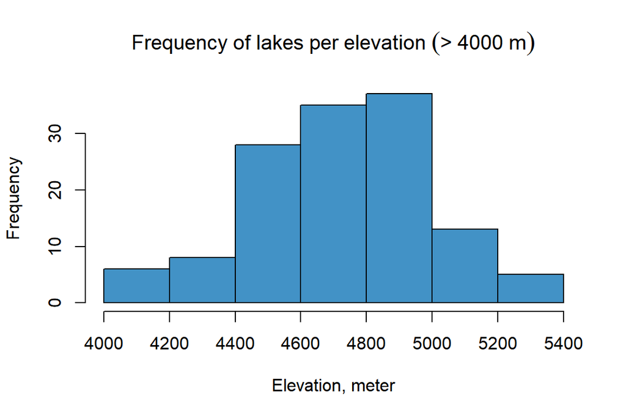

```r
hist(data[data$ELEV>4000,]$ELEV, main=expression(Frequency~of~lakes~per~
                                                   elevation~(">"~4000~m)),
     xlab="Elevation, meter", ylab="Frequency", col=blues[6])
```

```r
data[data$ELEV>4400,]$COUNTRY
```

```
##   [1] "China"     "China"     "China"     "China"     "China"     "China"
##   [7] "China"     "China"     "China"     "China"     "China"     "China"
##  [13] "China"     "China"     "China"     "China"     "China"     "China"
##  [19] "China"     "China"     "China"     "China"     "China"     "China"
##  [25] "China"     "China"     "China"     "China"     "China"     "China"
##  [31] "China"     "China"     "China"     "China"     "China"     "China"
##  [37] "China"     "China"     "India"     "China"     "China"     "China"
##  [43] "China"     "China"     "China"     "China"     "China"     "China"
##  [49] "China"     "China"     "China"     "China"     "China"     "China"
##  [55] "China"     "China"     "China"     "China"     "China"     "China"
##  [61] "China"     "China"     "China"     "China"     "China"     "China"
##  [67] "China"     "China"     "China"     "China"     "Argentina" "China"
##  [73] "China"     "China"     "China"     "China"     "China"     "China"
##  [79] "China"     "China"     "China"     "China"     "China"     "China"
##  [85] "China"     "China"     "China"     "China"     "China"     "China"
##  [91] "China"     "China"     "China"     "China"     "China"     "China"
##  [97] "China"     "China"     "China"     "China"     "China"     "China"
## [103] "China"     "China"     "China"     "China"     "China"     "China"
## [109] "China"     "China"     "China"     "China"     "China"     "China"
## [115] "China"     "China"     "China"     "Bolivia"
```

We see that the cluster of lakes at high altitudes consists of mostly lakes from China. This begs us to question how the dataset is formed. It would make sense that there would be more lakes at the altitudes between 1000m and 4000m meters as well. It might be they have been omitted from the dataset, or that they simply have not been mapped quite as extensively as the mountain lakes in China.

```r
data[data$ELEV>4400,]$AREA
```

```
##   [1] 1933.6 1640.9 1004.4  828.2  679.7  512.9  481.5  480.0  417.8  411.3
##  [11]  398.4  373.2  350.9  340.3  317.8  307.4  293.5  288.3  277.5  275.4
##  [21]  274.4  260.9  258.9  256.7  255.7  253.2  251.1  231.3  205.4  203.2
##  [31]  190.5  188.4  178.8  175.4  174.1  170.9  156.8  145.2  142.9  142.6
##  [41]  140.6  139.1  137.1  133.6  128.5  127.1  119.4  112.3  110.5  110.2
##  [51]  105.3  105.0  101.5  101.5  100.7  100.6  100.6  100.4   99.7   96.7
##  [61]   96.4   95.5   94.4   93.4   91.6   91.5   91.4   89.5   89.3   87.8
##  [71]   86.0   85.1   84.5   82.1   80.6   78.7   78.7   76.9   75.9   74.6
##  [81]   72.8   71.9   71.3   70.9   70.2   69.0   68.9   66.6   66.5   64.9
##  [91]   64.3   63.9   63.1   63.0   62.8   62.8   62.7   61.7   61.5   59.7
## [101]   59.7   59.0   58.6   58.2   57.6   57.4   56.8   56.6   55.8   54.9
## [111]   54.2   54.0   53.8   53.3   51.3   51.1   51.0   50.1
```

We also see that these lakes are quite varied in their size. Over half of the lakes are between 50 and 100 square kilometers in area, which we earlier saw is the most common size of lakes in the dataset.

# Distance calculator

Let’s make a coordinates-to-distance calculator, which we can use to calculate the distance between two lakes or reservoirs based on their coordinates. This is done using Great-circle distance, meaning that we are calculating the distance traveled on the surface of Earth. This has great inaccuracies when the compared points are very near, but since we are interested in greater distances, this should be a good approximation for us. The other option would be to project the sphere to a plane and calculate the straight distance, which would be better when the distances are short.

This method introduces some error, as Earth is assumed to be spherical, when in truth it is an ellipsoid.

See for more information: https://en.wikipedia.org/wiki/Great-circle_distance

```r
# R is the radius of earth (approximation based on spherical earth)
# ind1 and ind2 are the index of the lakes that we want to calculate the
# distance between data is the dataframe
calculate_distance <- function(R,ind1,ind2,data) {
# phi_1 is the latitude of the first lake
# phi_2 is the latitude of the second lake
phi_1 <- data$LAT[ind1]
phi_2 <- data$LAT[ind2]

# lambda_1 is the longitude of the first lake
# lambda_2 is the longitude of the second lake
lambda_1 <- data$LONG[ind1]
lambda_2 <- data$LONG[ind2]

# Convert the longitudes and latitudes to radians
phi_1_rad <- (pi/180) * phi_1
phi_2_rad <- (pi/180) * phi_2
lambda_1_rad <- (pi/180) * lambda_1
lambda_2_rad <- (pi/180) * lambda_2

# Calculate latitude and longitude difference
phi_diff<-abs(phi_1_rad-phi_2_rad)
lambda_diff<-abs(lambda_1_rad-lambda_2_rad)

# Calculate the central angle between the two points
sigma_diff1 <- acos((sin(phi_1_rad) * sin(phi_2_rad)) + (cos(phi_1_rad) *
                                    cos(phi_2_rad) * cos(lambda_diff)))

# Calculate the arc length -> the distance
D <- 6371.0 * sigma_diff1

# Distance
return(D)
}
calculate_distance(6371,1,2,data)
```

```
## [1] 9255.421
```

Using the distance calculation function, we can calculate the distance between each lake

```r
# Extract n, the sample size
n<-dim(data)[1]
# Use the distance calculation function on all pairs of lakes. This produces
# warnings on NaN-values produced, which we will deal with next.
suppressWarnings(DList<-lapply(1:n, function (x) {calculate_distance(R=6371,
                                              ind1=1:n, ind2=x, data=data)}))
# Convert the list to a matrix
DMat<-do.call(rbind, DList)
# Check NaN-values and collect their indices. They should all be zero,
# so we can simply correct them manually
nans<-which(is.na(DMat), arr.ind=TRUE)
# Set the NaN-values to zero
DMat[nans]<-0
# Check that there are no more NaN-values left
which(is.na(DMat), arr.ind=TRUE)
```

```
##      row col
```

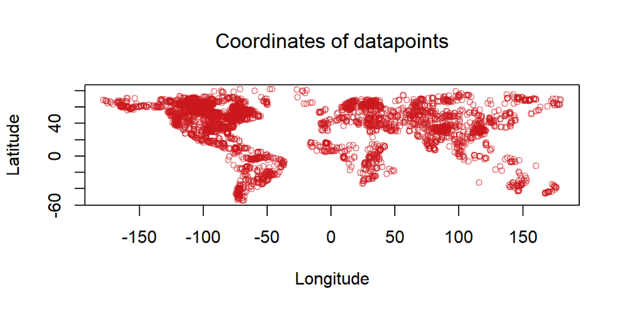

```r
plot(data$LONG, data$LAT, main=expression(Coordinates~of~datapoints),
     xlab="Longitude", ylab="Latitude", col=alpha("#CB181D", 0.5) , cex=0.8)
```

Next, to do clustering we need to normalize the numeric variables.

```r
# Normalize elevation and area
dataClust<-data[,c(4,8,12)]
z <- dataClust[,c(2,3)]
means <- apply(z,2,mean)
sds <- apply(z,2,sd)
nor <- scale(z,center=means,scale=sds)
distance = dist(nor)
```

For the clustering, we use the function hclust from base-R. To get the desired amount of groups, we cut the result tree with the function cutree.

```r
# Function for clustering and plotting the map with different colours based on the clustering
plotClusters <- function(distance, method, k, main="", xlab="", ylab="",
                         cols=c("#FFF5F0", "#FEE0D2", "#FCBBA1", "#FC9272",
                                "#FB6A4A", "#EF3B2C", "#C0181D", "#A00F15",
                                "#700000", "#400000"), alp=0.5, cex=0.5) {
ctreefull = hclust(distance, method=method)
ctreecut <- cutree(ctreefull, k)
sort(table(ctreecut))
names(table(ctreecut))
a<-cols[as.numeric(names(sort(table(ctreecut))))]
names(a)<-names(table(ctreecut))
ctreecut<-recode(ctreecut, !!!a, .default = NULL)
plot(data$LONG, data$LAT, col = alpha(ctreecut, alp), main=main, xlab=xlab,
     ylab=ylab, cex=cex)
}
```

Let’s start by testing the different methods for clustering. For each, we will do cutoff at 10 groups. From the documentation, we can find further information each method. These methods are applied as the linkage function in calculating the dissimilarities. Function formulas are from https://en.wikipedia.org/wiki/Hierarchical_clustering.

First is method ward.D. It is calculated as minimum increase of sum of squares:

$\Sigma_{x \in A \cup B}|| x - \mu_{A \cup B} || - \Sigma_{x \in A}|| x - \mu_A|| -\Sigma_{x \in B}|| x - \mu_B ||$

Further information on origins and history https://en.wikipedia.org/wiki/Ward%27s_method

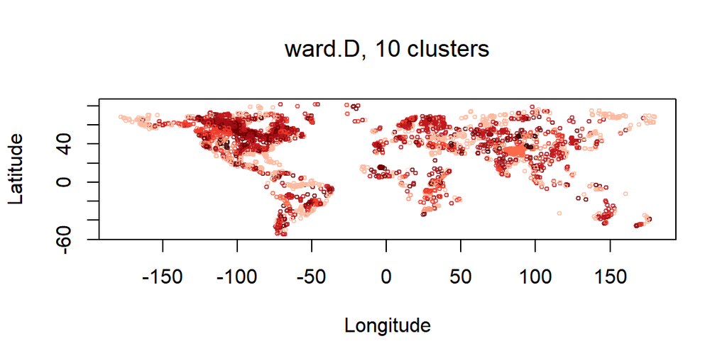

```r
plotClusters(distance=distance, method="ward.D", k=10,
             main=expression(paste(ward.D, ", ", 10~clusters)), xlab="Longitude",
             ylab="Latitude", cols=reds, alp=0.8)
```

Next, the very similar method ward.D2. The difference to ward.D is that the dissimilarities are squared before cluster updating:

$\frac{ |A| \cdot |B| }{ |A \cup B| } || {\mu_A}^2 - {\mu_B}^2 ||^2 = \Sigma_{x \in A \cup B} || x - \mu_{A \cup B} ||^2 - \Sigma_{x \in A}|| x - \mu_A||^2 -\Sigma_{x \in B}|| x - \mu_B ||^2$

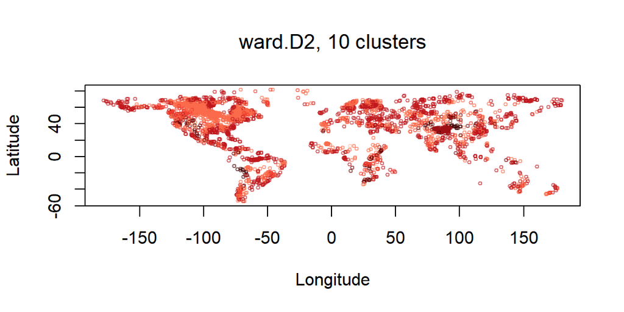

```r
plotClusters(distance=distance, method="ward.D2", k=10,
             main=expression(paste(ward.D2, ", ", 10~clusters)), xlab="Longitude",
             ylab="Latitude", reds, alp=0.6)
```

Due to the nature of the first Ward method and our distance matrix not having the distances squared, the second method should be used.

Next is the single method. The formula is given as

$\min \atop a \in A, b \in B$ $d(a, b)$

All lakes are in one group. Not much use from this method.

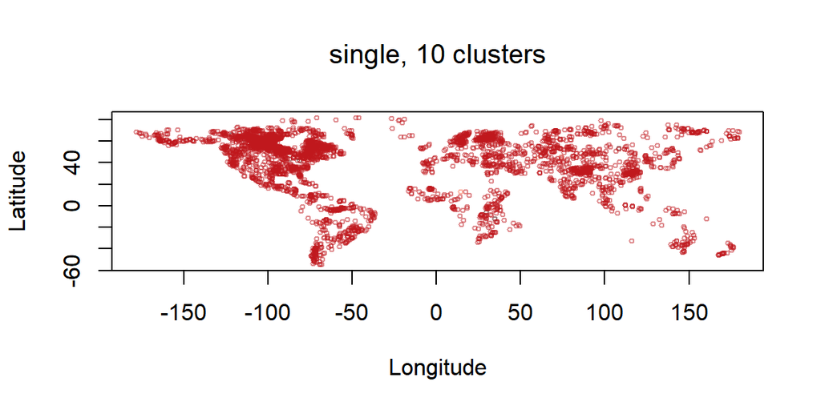

```r
plotClusters(distance=distance, method="single", k=10,
             main=expression(paste(single, ", ", 10~clusters)), xlab="Longitude",
             ylab="Latitude", reds, alp=0.5)
```

Next is the complete method. The formula is

$\max \atop a \in A, b \in B$ $d(a, b)$

Using this method we do find some clear groups, like the high altitude lakes in China, but a majority of the lakes in the dataset are still in a large group.

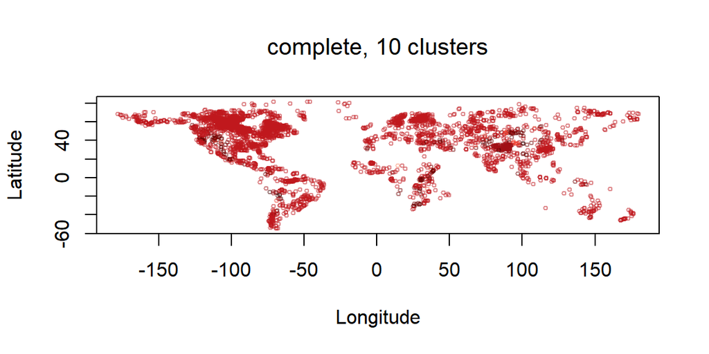

```r
plotClusters(distance=distance, method="complete", k=10,
             main=expression(paste(complete, ", ", 10~clusters)), xlab="Longitude",
             ylab="Latitude", reds, alp=0.5)
```

Next, the average method (UPGMA, unweighted average linkage clustering). The formula is

$\frac{1}{|A| \cdot |B|} \Sigma_{a \in A} \Sigma_{b \in B}~d(a,b)$

The results are very similar to the ones from using the complete method, however it seems some of the groups are even smaller.

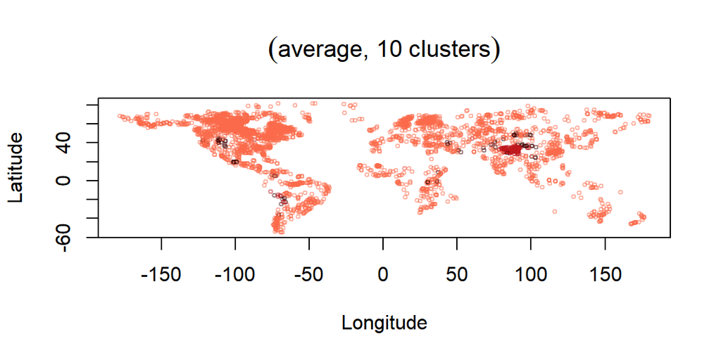

```r
# This seems very similar to the method complete.
plotClusters(distance=distance, method="average", k=10,
             main=expression((paste(average, ", ", 10~clusters)),~10~clusters), xlab="Longitude",
             ylab="Latitude", reds, alp=0.5)
```

Next, the mcquitty method (WPGMA, weighted average linkage clustering). The formula is

$d(i \cup j, k) = \frac {d(i,k)+d(j,k)}{2}$

Again, the results are very similar to the ones we got using the complete method.

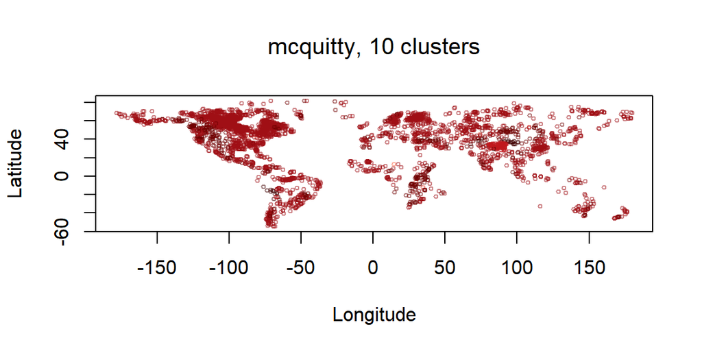

```r
plotClusters(distance=distance, method="mcquitty", k=10,
             main=expression(paste(mcquitty, ", ", 10~clusters)), xlab="Longitude",
             ylab="Latitude", reds, alp=0.5)
```

Next, the median method (WPGMC, median linkage clustering). The formula is

$d(i \cup j, k) = d(m_{i \cup j}, m_k)$, where $m_{i \cup j}=\frac{m_i + m_j}{2}$

The results are yet again very similar to the complete method, with most of the smaller groups slightly smaller.

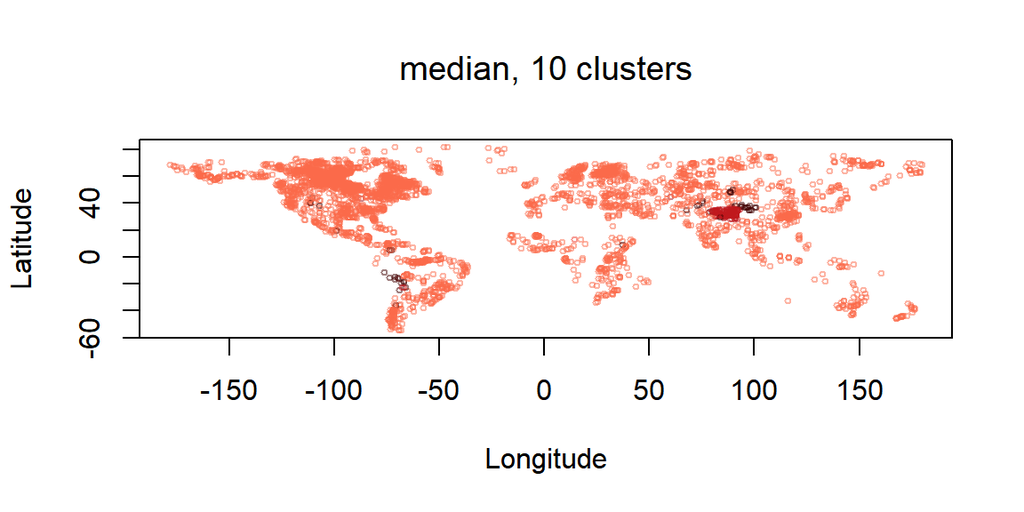

```r
plotClusters(distance=distance, method="median", k=10,
             main=expression(paste(median, ", ", 10~clusters)), xlab="Longitude",
             ylab="Latitude", reds, alp=0.5)
```

Finally, the centroid method (UPGMC, centroid linkage clustering). The formula is

$|| \mu_{a} - \mu_{b}||^2$, where $\mu_{a}$ and $\mu_{b}$ are the centroids of $A$ and $B$, respectively.

Again, we get very similar results.

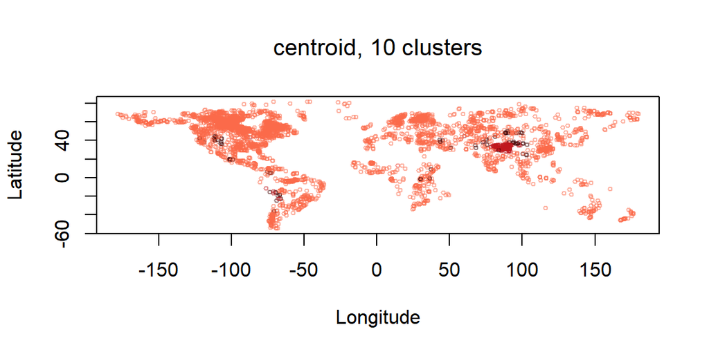

```r
plotClusters(distance=distance, method="centroid", k=10,
             main=expression(paste(centroid, ", ", 10~clusters)), xlab="Longitude",
             ylab="Latitude", reds, alp=0.5)
```

Next, let’s try to further refine our clustering using the method ward.D2, starting with only two groups and gradually increasing the amount.

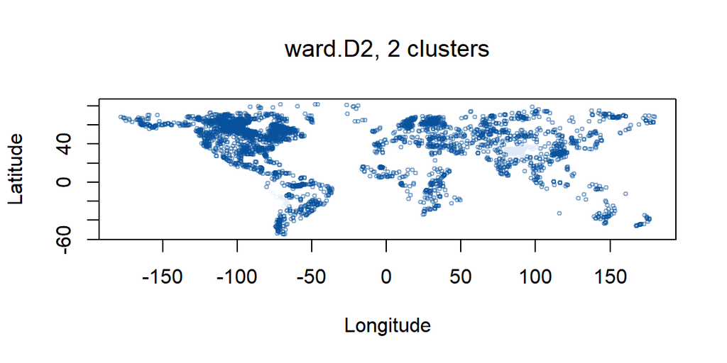

```r
plotClusters(distance=distance, method="ward.D2", k=2,
             main=expression(paste(ward.D2, ", ", 2~clusters)), xlab="Longitude",
             ylab="Latitude", blues[c(2,8)], alp=0.5)
```

Groups the high altitude lakes in China as well as some lakes in South America. Next, three groups.

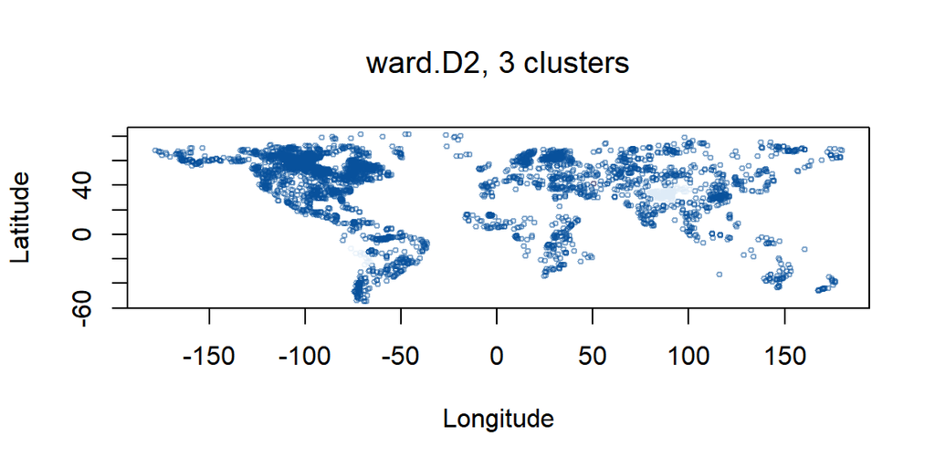

```r
plotClusters(distance=distance, method="ward.D2", k=3,
             main=expression(paste(ward.D2, ", ", 3~clusters)), xlab="Longitude",
             ylab="Latitude", blues[c(10,2,8)], alp=0.5)
```

The grouping is largely the same, the new third group has only a couple members, coloured black.

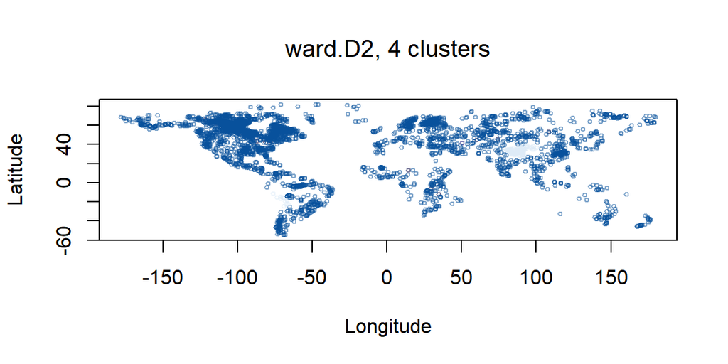

```r
plotClusters(distance=distance, method="ward.D2", k=4,
             main=expression(paste(ward.D2, ", ", 4~clusters)), xlab="Longitude",
             ylab="Latitude", blues[c(9,10,2,8)], alp=0.5)
```

Continuing with the trend, there is an additional level of grouping.

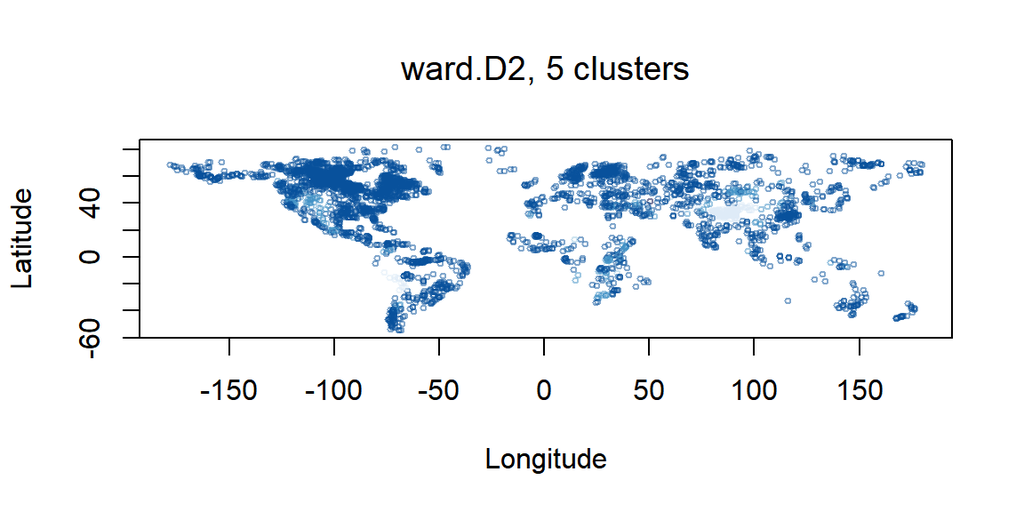

```r
plotClusters(distance=distance, method="ward.D2", k=5,
             main=expression(paste(ward.D2, ", ", 5~clusters)), xlab="Longitude",
             ylab="Latitude", blues[c(10,4,6,8,2)], alp=0.5)
```

Now we start to see some meaningful groups forming.

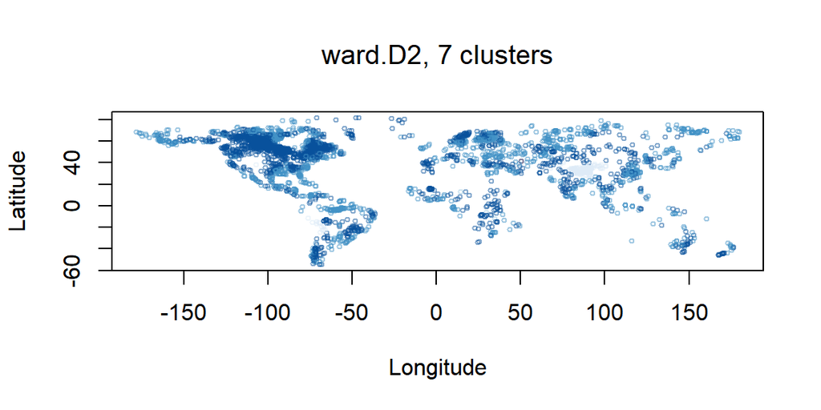

```r
plotClusters(distance=distance, method="ward.D2", k=7,
             main=expression(paste(ward.D2, ", ", 7~clusters)), xlab="Longitude",
             ylab="Latitude", blues[c(10,1,4,6,8,2)], alp=0.5)
```

Further groups are developing. There does not appear to be a very dominant group at this point.

Next, let’s do the same to the method complete.

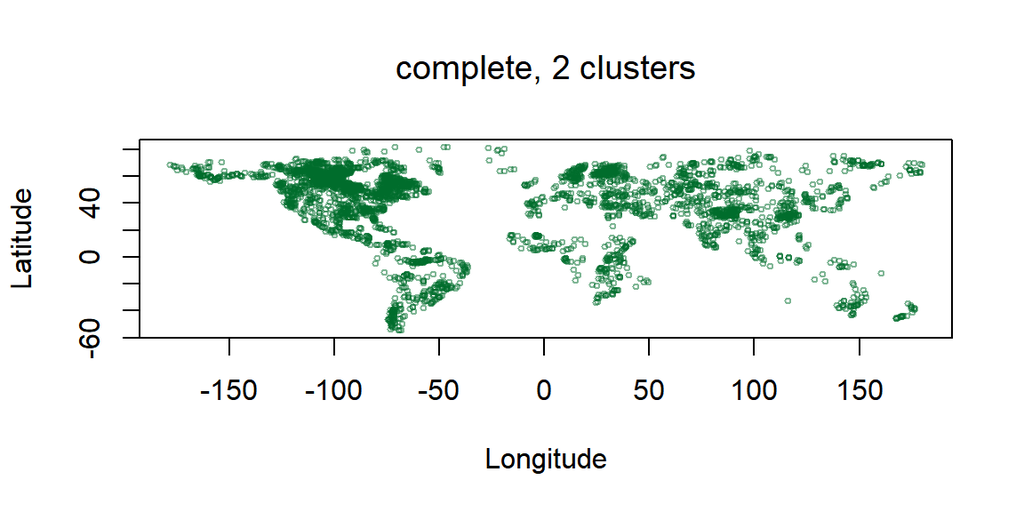

```r
plotClusters(distance=distance, method="complete", k=2,
             main=expression(paste(complete, ", ", 2~clusters)), xlab="Longitude",
             ylab="Latitude", greens[c(2,8)], alp=0.5)
```

Only one large group. Let’s add groups until we see a change.

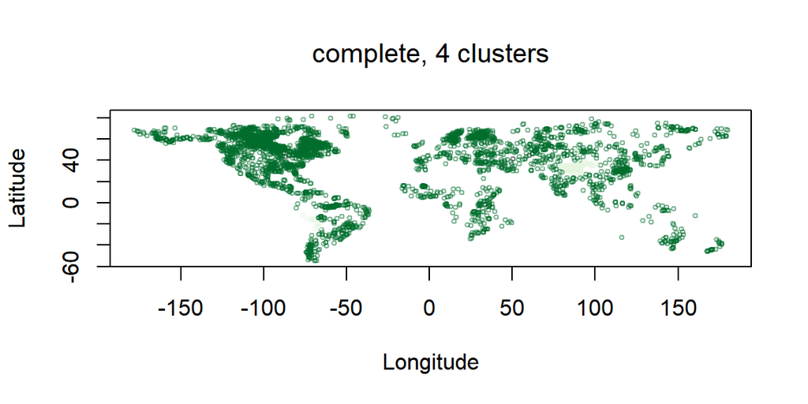

```r
plotClusters(distance=distance, method="complete", k=4,
             main=expression(paste(complete, ", ", 4~clusters)), xlab="Longitude",
             ylab="Latitude", greens[c(10,10,2,8)], alp=0.5)
```

Now we see the high altitude lakes in their own group. However, two of the groups are not to be seen on the map.

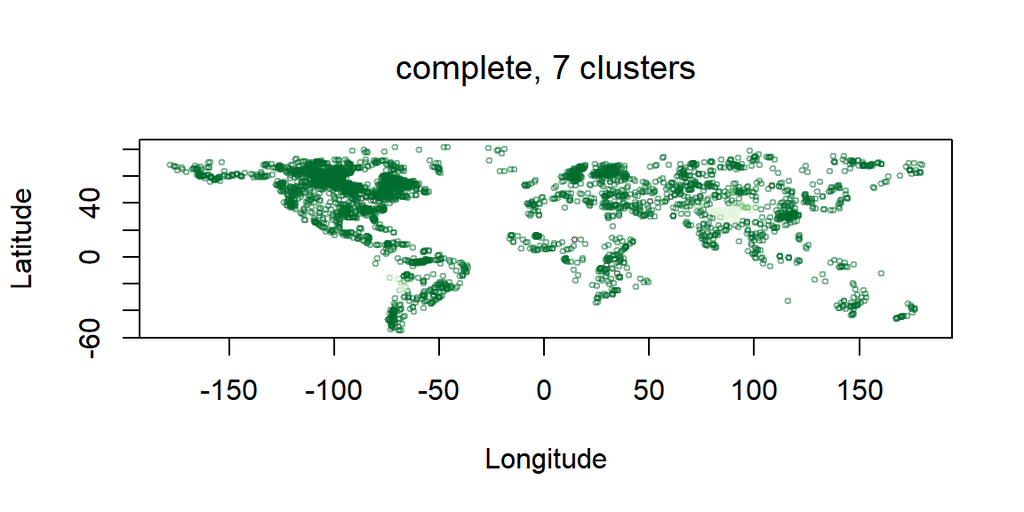

```r
plotClusters(distance=distance, method="complete", k=7,
             main=expression(paste(complete, ", ", 7~clusters)), xlab="Longitude",
             ylab="Latitude", greens[c(10, 10, 10, 10, 2, 8, 5)], alp=0.5)
```

One more group that we can actually see on the map. This method does not seem to be very useful, as a large part of the groups end up being very small.

Let’s try to further refine the method average

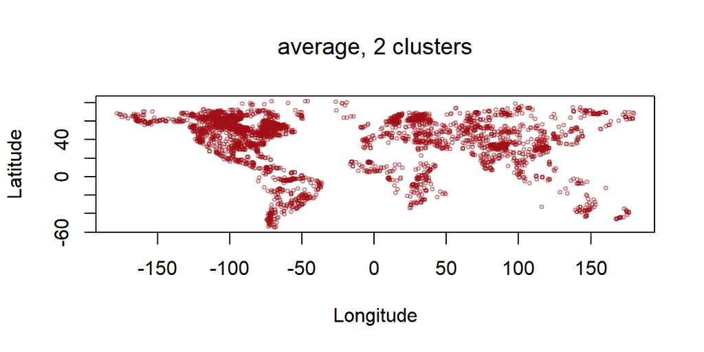

```r
plotClusters(distance=distance, method="average", k=2,
             main=expression(paste(average, ", ", 2~clusters)), xlab="Longitude",
             ylab="Latitude", reds[c(2,8)], alp=0.5)
```

Again, there is only one group.

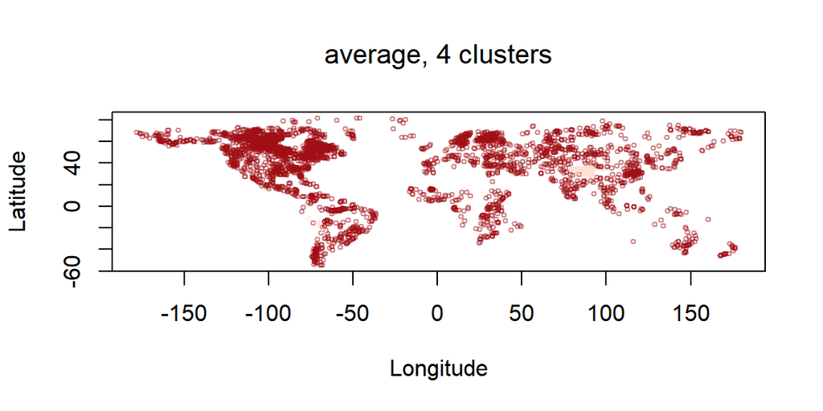

```r
plotClusters(distance=distance, method="average", k=4,
             main=expression(paste(average, ", ", 4~clusters)), xlab="Longitude",
             ylab="Latitude", reds[c(10, 10, 2, 8)], alp=0.5)
```

Similar to with method complete, we get the grouping of the high altitude lakes when we make four groups.

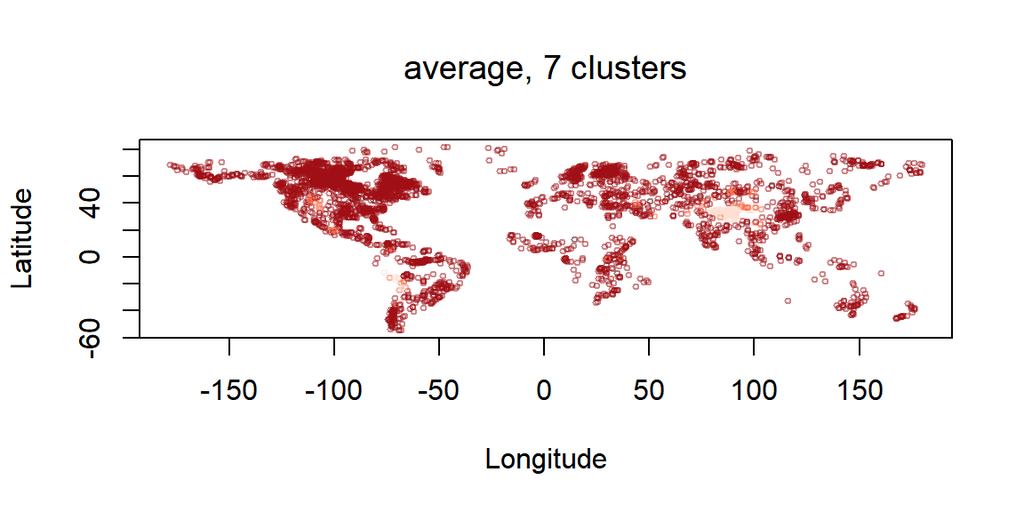

```r
plotClusters(distance=distance, method="average", k=7,
             main=expression(paste(average, ", ", 7~clusters)), xlab="Longitude",
             ylab="Latitude", reds[c(10, 10, 10, 10, 5, 2, 8)], alp=0.5)
```

Yet again, we need to have seven groups total until we get a meaningful third group. The analysis is almost identical to the one with method complete.

Secondly, let’s do the same thing but utilizing the distance matrix we got using the distance calculator. Now, we will use the function hclustgeo. The function is supplied with the two distance matrices, D0 and D1, as well as a scaling parameter alpha, which specifies the relative importance between D0 and D1. The parameter should be between 0 and 1. Lower values result in D0 having more importance while values closer to 1 give D1 more importance. This means that we need to find a good balancing value for alpha.